# How Do You Do ‘You Do You’?

Exploring American Time Use · STA 9750 Mini-Project #02

Author

Published

April 2, 2026

# ⏱ How Do You Do “You Do You”?

**Market Research on American Time Use · ATUS 2003–2024**  
Exploring how 250,000+ Americans spend their days — and what that means for a new time-tracking app.

## Executive Summary

How do Americans *actually* spend their time? This report digs into more than two decades of data from the **American Time Use Survey (ATUS)** — a nationally representative panel jointly run by the Bureau of Labor Statistics and the US Census Bureau. Using the 2003–2024 Public Use Microdata, I uncover how time allocation varies by age, gender, employment, family structure, and income — and apply those insights to build market research personas for a hypothetical time-management app.

## 1 · Data Acquisition

Task 1

**🔍 Show Code**

```r
load_atus_data <- function(file_base = c("resp", "rost", "act")) {
  if (!dir.exists(file.path("data", "mp02")))
    dir.create(file.path("data", "mp02"), showWarnings = FALSE, recursive = TRUE)

  file_base     <- match.arg(file_base)
  file_name_out <- file.path("data", "mp02", glue("atus{file_base}_0324.dat"))

  if (!file.exists(file_name_out)) {
    temp_zip <- tempfile(fileext = ".zip")
    request("https://www.bls.gov") |>
      req_url_path("tus", "datafiles", glue("atus{file_base}-0324.zip")) |>
      req_headers(`User-Agent` = paste0(
        "Mozilla/5.0 (Macintosh; Intel Mac OS X 10.15; rv:149.0) ",
        "Gecko/20100101 Firefox/149.0")) |>
      req_perform(temp_zip)
    temp_dir <- tools::file_path_sans_ext(temp_zip)
    unzip(temp_zip, exdir = temp_dir)
    file.copy(file.path(temp_dir, basename(file_name_out)), file_name_out)
  }

  file <- read_csv(file_name_out, show_col_types = FALSE)

  # ── Respondent file ─────────────────────────────────────────────────────────
  # IMPORTANT: TEAGE and TESEX are in the ROSTER file, not here.
  # PEMARITL, HEFAMINC, PEEDUCA are CPS-only and not on this file.
  if (file_base == "resp") {
    return(
      file |>
        rename(
          participant_id  = TUCASEID,
          survey_weight   = TUFNWGTP,
          time_alone      = TRTALONE,
          survey_year     = TUYEAR,
          interview_month = TUMONTH,
          n_children      = TRCHILDNUM
        ) |>
        mutate(
          is_summer = interview_month %in% c(6, 7, 8),

          # TELFS: 1=Employed@work, 2=Employed-absent,
          #        3=Unemployed-layoff, 4=Unemployed-looking,
          #        5=Not in labor force  (only 5 values in combined file)
          employment_status = case_match(TELFS,
            1 ~ "Employed (At Work)",
            2 ~ "Employed (Absent)",
            3 ~ "Unemployed (Layoff)",
            4 ~ "Unemployed (Looking)",
            5 ~ "Not in Labor Force",
            .default = NA_character_),
          is_employed  = TELFS %in% c(1, 2),

          # TURETOT: 1=Yes still retired, 2=No, 3=Was not retired previously
          is_retired   = !is.na(TURETOT) & TURETOT == 1,

          # TRDPFTPT: 1=Full time, 2=Part time (only defined for employed)
          is_full_time = !is.na(TRDPFTPT) & TRDPFTPT == 1,

          # Marital proxy: TRSPPRES (1=Spouse present, 2=Partner, 3=No partner)
          is_married = TRSPPRES == 1,
          partner_status = case_match(TRSPPRES,
            1 ~ "Married",
            2 ~ "Partnered (Unmarried)",
            3 ~ "No Partner",
            .default = NA_character_),

          # College enrollment: TESCHENR=1 (enrolled) + TESCHLVL=2 (college/univ)
          # Note: variable is TESCHLVL, NOT TESCH
          is_college_student = !is.na(TESCHENR) & TESCHENR == 1 &
                               !is.na(TESCHLVL) & TESCHLVL == 2,

          # Income proxy from TRERNWA (weekly earnings at main job, 2 implied decimals)
          # Divide by 100 for dollars/week; multiply by 52 for annual estimate
          # Only defined for employed wage/salary workers; -1 for others
          weekly_earn_usd = if_else(TRERNWA > 0, TRERNWA / 100, NA_real_),
          annual_earn_est = weekly_earn_usd * 52,
          is_high_income  = !is.na(annual_earn_est) & annual_earn_est >= 100000,
          income_group = case_when(
            is.na(annual_earn_est)    ~ NA_character_,
            annual_earn_est <  35000  ~ "Under $35k",
            annual_earn_est <  75000  ~ "$35k-$75k",
            annual_earn_est < 115000  ~ "$75k-$115k",
            TRUE                      ~ "$115k+"),

          # Education sector: TRDTIND1 == 15 is Educational Services
          in_education_sector = !is.na(TRDTIND1) & TRDTIND1 == 15
        ) |>
        select(matches("[:lower:]", ignore.case = FALSE))
    )
  }

  # ── Roster file ─────────────────────────────────────────────────────────────
  # TEAGE and TESEX live here. Add line_number to filter to respondent (line 1).
  if (file_base == "rost") {
    return(
      file |>
        rename(participant_id = TUCASEID) |>
        mutate(
          age         = TEAGE,
          sex         = case_match(TESEX, 1 ~ "Male", 2 ~ "Female"),
          line_number = TULINENO
        ) |>
        select(matches("[:lower:]", ignore.case = FALSE))
    )
  }

  # ── Activity file ───────────────────────────────────────────────────────────
  # TUMONTH is NOT on this file — use interview_month from resp and join when needed.
  file |>
    rename(participant_id = TUCASEID) |>
    mutate(
      activity_n_of_day = TUACTIVITY_N,
      time_spent_min    = TUACTDUR24,
      start_time        = TUSTARTTIM,
      stop_time         = TUSTOPTIME,
      level1_code = formatC(TRTIER1P, width = 2, flag = "0") |> paste0("0000"),
      level2_code = formatC(TRTIER2P, width = 4, flag = "0") |> paste0("00"),
      level3_code = formatC(TRCODEP,  width = 6, flag = "0"),

      # TEWHERE codes per BLS 2003-2024 codebook
      activity_location = case_match(TEWHERE,
        1  ~ "Home/Yard",           2  ~ "Workplace",
        3  ~ "Someone Else's Home", 4  ~ "Restaurant/Bar",
        5  ~ "Place of Worship",    6  ~ "Grocery Store",
        7  ~ "Other Store/Mall",    8  ~ "School",
        9  ~ "Outdoors",           10  ~ "Library",
        11 ~ "Other Indoor Place", 12  ~ "Car (Driver)",
        13 ~ "Car (Passenger)",    14  ~ "Walking",
        15 ~ "Bus",                16  ~ "Subway/Train",
        17 ~ "Bicycle",            18  ~ "Boat/Ferry",
        19 ~ "Taxi/Limousine",     20  ~ "Airplane",
        21 ~ "Other Transport",    30  ~ "Bank",
        31 ~ "Gym/Health Club",    32  ~ "Post Office",
        .default = "Unspecified"),

      # Bus=15, Subway/Train=16, Boat/Ferry=18
      on_transit = TEWHERE %in% c(15, 16, 18)
    ) |>
    select(matches("[:lower:]", ignore.case = FALSE))
}

load_atus_activities <- function() {
  if (!dir.exists(file.path("data", "mp02")))
    dir.create(file.path("data", "mp02"), showWarnings = FALSE, recursive = TRUE)
  dest <- file.path("data", "mp02", "atus_activity_codes.csv")
  if (!file.exists(dest))
    download.file(
      "https://michael-weylandt.com/STA9750/mini/atus_activity_codes.csv",
      quiet = TRUE, destfile = dest, mode = "wb")
  read_csv(dest, show_col_types = FALSE)
}
```

**🔍 Show Code**

```r
atus_resp  <- load_atus_data("resp")
atus_rost  <- load_atus_data("rost")
atus_act   <- load_atus_data("act")
atus_codes <- load_atus_activities()

# Age and sex live in the roster file (line_number == 1 is the respondent).
# Join them into atus_resp now so all downstream code can use age/sex directly.
atus_resp <- atus_resp |>
  left_join(
    atus_rost |>
      filter(line_number == 1) |>
      select(participant_id, age, sex),
    join_by(participant_id))

# atus_activity_codes.csv columns (verified):
#   code_level1, code_level2, code_level3  (6-digit strings)
#   task_level1, task_level2, task_level3  (labels)
# Create de-duplicated lookup tables for each tier.
codes_l1 <- atus_codes |> distinct(code_level1, task_level1)
codes_l2 <- atus_codes |> distinct(code_level2, task_level2)
codes_l3 <- atus_codes |> distinct(code_level3, task_level3)
```

**🔍 Show Code**

```r
tibble(
  Table = c("Respondent", "Roster", "Activity", "Activity Codes"),
  Rows  = c(nrow(atus_resp), nrow(atus_rost), nrow(atus_act), nrow(atus_codes)),
  Cols  = c(ncol(atus_resp), ncol(atus_rost), ncol(atus_act), ncol(atus_codes))
) |>
  gt() |>
  tab_header("ATUS Data Inventory") |>
  fmt_number(columns = Rows, decimals = 0) |>
  tab_style(style = cell_fill(color = "#eaf4fb"),
            locations = cells_column_labels()) |>
  tab_source_note("BLS American Time Use Survey 2003-2024 combined files")
```

ATUS Data Inventory

| Table | Rows | Cols |
| --- | --- | --- |
| Respondent | 252,808 | 21 |
| Roster | 687,357 | 4 |
| Activity | 4,880,021 | 10 |
| Activity Codes | 477 | 6 |

BLS American Time Use Survey 2003-2024 combined files

## 2 · Data Cleaning & Preparation

### 2.1 Join Design Practice

Task 2

**Q1 — Total hours on sleeping activities**

1. Connect `time_spent_min` from `atus_act` with a sleeping filter from `atus_codes`
2. Common key: `level2_code` matches `code_level2`; filter to `"010100"` (Sleeping)
3. Only want rows that match → **`inner_join`**

**🔍 Show Code**

```r
total_sleep_hrs <- atus_act |>
  filter(level2_code == "010100") |>
  summarize(total_hrs = sum(time_spent_min, na.rm = TRUE) / 60)

total_sleep_hrs
```

| total_hrs |
| --- |
| 2241332 |

**Q2 — Female respondents with no time alone in 2003**

Age and sex are now in `atus_resp` (joined from roster), so no extra join is needed.

**🔍 Show Code**

```r
no_alone_2003_f <- atus_resp |>
  filter(sex == "Female", survey_year == 2003, time_alone == 0) |>
  nrow()

no_alone_2003_f
```

```
[1] 884
```

### 2.2 Demographic Variable Extensions

Task 3

The modified `load_atus_data()` adds the following variables. Key corrections from the BLS codebook:

- **`age` / `sex`**: from `TEAGE` / `TESEX` in the *roster* file (joined to resp via `line_number == 1`)
- **`is_married`**: from `TRSPPRES == 1` (spouse present) — `PEMARITL` is CPS-only, not on this file
- **`income_group`**: from `TRERNWA` (weekly earnings) — `HEFAMINC` is CPS-only
- **`is_college_student`**: `TESCHENR == 1` and `TESCHLVL == 2` — variable is `TESCHLVL`, not `TESCH`
- **`is_retired`**: from `TURETOT == 1` (still retired flag)
- **`in_education_sector`**: `TRDTIND1 == 15` (Educational Services industry recode)
- **`is_summer`**: from `TUMONTH` which is on resp — *not* on the activity file
- **`on_transit`**: `TEWHERE %in% c(15, 16, 18)` (Bus, Subway/Train, Boat/Ferry per codebook)

**🔍 Show Code**

```r
atus_resp |>
  select(age, sex, n_children, partner_status, employment_status, is_college_student) |>
  slice_sample(n = 8) |>
  gt() |>
  tab_header("Sample Rows — Extended Respondent File") |>
  tab_style(style = cell_fill(color = "#eaf4fb"),
            locations = cells_column_labels())
```

Sample Rows — Extended Respondent File

| age | sex | n_children | partner_status | employment_status | is_college_student |
| --- | --- | --- | --- | --- | --- |
| 42 | Female | 3 | Married | Employed (Absent) | FALSE |
| 35 | Female | 2 | Married | Not in Labor Force | FALSE |
| 45 | Male | 1 | Married | Employed (At Work) | FALSE |
| 80 | Female | 0 | No Partner | Not in Labor Force | FALSE |
| 48 | Male | 2 | Married | Not in Labor Force | FALSE |
| 18 | Female | 0 | No Partner | Not in Labor Force | FALSE |
| 25 | Male | 0 | No Partner | Employed (At Work) | FALSE |
| 48 | Male | 0 | No Partner | Employed (At Work) | FALSE |

## 3 · Exploratory Data Analysis

### 3.1 Key Figures at a Glance

Task 4

Over the 21-year span of ATUS data, **252,808** unique Americans have responded to the survey.

ATUS tracks **33** distinct sports-watching activities at the Level-3 classification — from baseball to the Olympics.

Approximately **15.4%** of the adult US population identifies as retired.

On average, Americans sleep **8.8 hours** per day.

Among respondents with at least one child under 18, parents spend **1.9 hours** per day on child-care activities.

252,808

Total Respondents

8.8h

Avg Daily Sleep

15.4%

Retired Population

1.9h

Avg Parent Childcare

### 3.2 Table Explorations

Task 5

**🌿 Lawn Care: Retired vs. Employed**

**🔍 Show Code**

```r
# code_level2 "020500" = "Lawn, Garden, and Houseplants"
lawn_care <- atus_act |>
  filter(level2_code == "020500") |>
  inner_join(
    atus_resp |> select(participant_id, survey_weight,
                        is_employed, is_retired),
    join_by(participant_id)) |>
  mutate(status_group = case_when(
    is_retired  ~ "Retired",
    is_employed ~ "Employed",
    TRUE        ~ "Other / Not in Labor Force")) |>
  group_by(participant_id, status_group) |>
  summarize(daily_min    = sum(time_spent_min, na.rm = TRUE),
            survey_weight = first(survey_weight), .groups = "drop") |>
  group_by(status_group) |>
  summarize(avg_min_day  = weighted.mean(daily_min, survey_weight),
            avg_hrs_week = avg_min_day * 7 / 60,
            n            = n(), .groups = "drop") |>
  arrange(desc(avg_min_day))

lawn_care |>
  gt() |>
  tab_header(title    = "Time Spent on Lawn & Garden Activities",
             subtitle = "Weighted daily averages by employment status") |>
  cols_label(status_group = "Status", avg_min_day = "Avg Min/Day",
             avg_hrs_week = "Avg Hrs/Week", n = "Respondents") |>
  fmt_number(columns = c(avg_min_day, avg_hrs_week), decimals = 1) |>
  fmt_number(columns = n, decimals = 0) |>
  tab_style(
    style     = list(cell_fill(color = "#eaf4fb"), cell_text(weight = "bold")),
    locations = cells_body(rows = status_group == "Retired")) |>
  tab_source_note("Source: ATUS 2003-2024 (population-weighted)")
```

Time Spent on Lawn & Garden Activities

Weighted daily averages by employment status

| Status | Avg Min/Day | Avg Hrs/Week | Respondents |
| --- | --- | --- | --- |
| Retired | 123.6 | 14.4 | 8,110 |
| Other / Not in Labor Force | 117.1 | 13.7 | 4,356 |
| Employed | 116.7 | 13.6 | 14,298 |

Source: ATUS 2003-2024 (population-weighted)

**👫 Social Activities: Married vs. Unmarried**

**🔍 Show Code**

```r
# code_level1 "120000" = Socializing, Relaxing, and Leisure
social_time <- atus_act |>
  filter(level1_code == "120000") |>
  inner_join(
    atus_resp |> select(participant_id, survey_weight, is_married),
    join_by(participant_id)) |>
  group_by(participant_id, is_married) |>
  summarize(daily_min    = sum(time_spent_min, na.rm = TRUE),
            survey_weight = first(survey_weight), .groups = "drop") |>
  group_by(is_married) |>
  summarize(avg_min_day  = weighted.mean(daily_min, survey_weight),
            avg_hrs_week = avg_min_day * 7 / 60,
            n            = n(), .groups = "drop") |>
  mutate(label = if_else(is_married, "Married (Spouse Present)", "Not Married"))

social_time |>
  select(label, avg_min_day, avg_hrs_week, n) |>
  gt() |>
  tab_header(title    = "Social & Leisure Time by Marital Status",
             subtitle = "Weighted average daily minutes") |>
  cols_label(label = "Status", avg_min_day = "Avg Min/Day",
             avg_hrs_week = "Avg Hrs/Week", n = "Respondents") |>
  fmt_number(columns = c(avg_min_day, avg_hrs_week), decimals = 1) |>
  fmt_number(columns = n, decimals = 0) |>
  tab_source_note("Source: ATUS 2003-2024 (population-weighted)")
```

Social & Leisure Time by Marital Status

Weighted average daily minutes

| Status | Avg Min/Day | Avg Hrs/Week | Respondents |
| --- | --- | --- | --- |
| Not Married | 316.6 | 36.9 | 120,487 |
| Married (Spouse Present) | 275.4 | 32.1 | 120,279 |

Source: ATUS 2003-2024 (population-weighted)

Unmarried Americans report more social and leisure time, consistent with married individuals facing greater time constraints from household and caregiving obligations.

**💰 High-Earner Time Use**

**🔍 Show Code**

```r
# is_high_income = annual_earn_est >= $100k (TRERNWA-based)
high_income_time <- atus_act |>
  inner_join(
    atus_resp |> filter(is_high_income) |> select(participant_id, survey_weight),
    join_by(participant_id)) |>
  inner_join(codes_l1, join_by(level1_code == code_level1)) |>
  group_by(participant_id, task_level1) |>
  summarize(daily_min    = sum(time_spent_min, na.rm = TRUE),
            survey_weight = first(survey_weight), .groups = "drop") |>
  group_by(task_level1) |>
  summarize(avg_min_day = weighted.mean(daily_min, survey_weight),
            .groups = "drop") |>
  arrange(desc(avg_min_day)) |>
  slice_head(n = 8)

high_income_time |>
  mutate(avg_hrs = avg_min_day / 60) |>
  gt() |>
  tab_header(title    = "Top Time Uses for High-Income Americans",
             subtitle = "Respondents with estimated annual earnings >= $100,000") |>
  cols_label(task_level1 = "Activity", avg_min_day = "Avg Min/Day",
             avg_hrs = "Avg Hrs/Day") |>
  fmt_number(columns = c(avg_min_day, avg_hrs), decimals = 1) |>
  data_color(columns = avg_min_day, palette = c("#eaf4fb","#1a5276")) |>
  tab_source_note("Income estimated from TRERNWA (weekly earnings x 52)")
```

Top Time Uses for High-Income Americans

Respondents with estimated annual earnings >= $100,000

| Activity | Avg Min/Day | Avg Hrs/Day |
| --- | --- | --- |
| Personal Care | 529.6 | 8.8 |
| Work and Work-Related Activities | 485.6 | 8.1 |
| Socializing, Relaxing, and Leisure | 207.7 | 3.5 |
| Education | 168.5 | 2.8 |
| Household Activities | 115.0 | 1.9 |
| Volunteer Activities | 101.9 | 1.7 |
| Caring for and Helping Household Members | 99.4 | 1.7 |
| Traveling | 95.5 | 1.6 |

Income estimated from TRERNWA (weekly earnings x 52)

Even for high earners, sleep and work dominate — a sobering reminder that money cannot buy more hours.

**🚌 Activities on Transit**

**🔍 Show Code**

```r
# Bus=15, Subway/Train=16, Boat/Ferry=18 per BLS codebook
transit_activities <- atus_act |>
  filter(on_transit) |>
  inner_join(codes_l2, join_by(level2_code == code_level2)) |>
  count(task_level2, wt = time_spent_min, name = "total_min") |>
  arrange(desc(total_min)) |>
  slice_head(n = 10) |>
  mutate(total_hrs  = total_min / 60,
         pct_of_top = total_min / sum(total_min))

transit_activities |>
  select(task_level2, total_hrs, pct_of_top) |>
  gt() |>
  tab_header(title    = "Top Activities While on Public Transit",
             subtitle = "Bus, subway/train, and boat/ferry (TEWHERE = 15, 16, 18)") |>
  cols_label(task_level2 = "Activity", total_hrs = "Total Hours",
             pct_of_top = "% of Top 10") |>
  fmt_number(columns = total_hrs, decimals = 0) |>
  fmt_percent(columns = pct_of_top, decimals = 1) |>
  data_color(columns = pct_of_top, palette = c("#fef9f3","#e67e22")) |>
  tab_source_note("Source: ATUS 2003-2024")
```

Top Activities While on Public Transit

Bus, subway/train, and boat/ferry (TEWHERE = 15, 16, 18)

| Activity | Total Hours | % of Top 10 |
| --- | --- | --- |
| Travel Related to Work | 2,912 | 32.5% |
| Travel Related to Socializing, Relaxing, and Leisure | 1,471 | 16.4% |
| Travel Related to Consumer Purchases | 1,138 | 12.7% |
| Travel Related to Eating and Drinking | 833 | 9.3% |
| Travel Related to Education | 785 | 8.8% |
| Participating in Sports, Exercise, or Recreation | 586 | 6.5% |
| Travel Related to Household Activities | 330 | 3.7% |
| Travel Related to Sports, Exercise, and Recreation | 317 | 3.5% |
| Travel Related to Using Professional and Personal Care Services | 308 | 3.4% |
| Traveling, n.e.c. | 290 | 3.2% |

Source: ATUS 2003-2024

Transit time is dominated by commuting-adjacent activities, but leisure reclaiming of otherwise lost minutes is well represented.

**🎯 My Four Favorite Activities by Age**

My four favorite activities are **Reading**, **Running**, **Cooking**, and **Socializing**.

**🔍 Show Code**

```r
# Level-3 codes verified against atus_activity_codes.csv:
# 120312 = "Reading for personal interest"
# 130124 = "Running"
# 020201 = "Food and drink preparation"
# 120101 = "Socializing and communicating with others"
fav_codes  <- c("120312", "130124", "020201", "120101")
fav_labels <- c("120312" = "Reading",
                "130124" = "Running",
                "020201" = "Cooking",
                "120101" = "Socializing")

fav_time <- atus_act |>
  filter(level3_code %in% fav_codes) |>
  inner_join(atus_resp |> select(participant_id, survey_weight, age),
             join_by(participant_id)) |>
  filter(!is.na(age)) |>
  mutate(
    activity_name = recode(level3_code, !!!fav_labels),
    age_group = cut(age,
      breaks = c(14, 24, 34, 44, 54, 64, Inf),
      labels = c("15-24","25-34","35-44","45-54","55-64","65+"),
      right  = TRUE)) |>
  group_by(activity_name, age_group) |>
  summarize(avg_min = weighted.mean(time_spent_min, survey_weight, na.rm = TRUE),
            .groups = "drop") |>
  pivot_wider(names_from = age_group, values_from = avg_min)

fav_time |>
  gt() |>
  tab_header(title    = "Daily Minutes on My Four Favorite Activities",
             subtitle = "Population-weighted averages by age group") |>
  cols_label(activity_name = "Activity") |>
  fmt_number(columns = -activity_name, decimals = 1) |>
  data_color(columns = -activity_name,
             palette = c("#ffffff","#1a5276"), na_color = "#f5f5f5") |>
  tab_source_note("Source: ATUS 2003-2024")
```

Daily Minutes on My Four Favorite Activities

Population-weighted averages by age group

| Activity | 15-24 | 25-34 | 35-44 | 45-54 | 55-64 | 65+ |
| --- | --- | --- | --- | --- | --- | --- |
| Cooking | 30.2 | 31.6 | 31.1 | 31.8 | 31.0 | 31.3 |
| Reading | 66.8 | 55.6 | 54.0 | 56.2 | 62.1 | 70.8 |
| Running | 52.2 | 44.7 | 46.9 | 50.8 | 54.2 | 52.8 |
| Socializing | 70.0 | 72.9 | 65.9 | 65.6 | 66.3 | 71.8 |

Source: ATUS 2003-2024

### 3.3 Graphical Explorations

Task 6

**🏠 Household Activities vs. Age**

**🔍 Show Code**

[figure not shown]

```r
# code_level1 "020000" = Household Activities
household_by_age <- atus_act |>
  filter(level1_code == "020000") |>
  inner_join(atus_resp |> select(participant_id, survey_weight, age, sex),
             join_by(participant_id)) |>
  filter(!is.na(age), !is.na(sex), age >= 15, age <= 80) |>
  mutate(age_group = cut(age, breaks = seq(15, 80, by = 5),
                         right = FALSE, include.lowest = TRUE)) |>
  group_by(age_group, sex) |>
  summarize(avg_min = weighted.mean(time_spent_min, survey_weight, na.rm = TRUE),
            .groups = "drop") |>
  mutate(age_mid = as.numeric(str_extract(as.character(age_group), "\\d+")) + 2.5)

ggplot(household_by_age, aes(x = age_mid, y = avg_min, color = sex, fill = sex)) +
  geom_ribbon(aes(ymin = avg_min * 0.9, ymax = avg_min * 1.1),
              alpha = 0.15, color = NA) +
  geom_line(linewidth = 1.2) +
  geom_point(size = 2.5, shape = 21, color = "white", stroke = 1.5) +
  scale_color_manual(values = c("Female" = "#e67e22","Male" = "#1a5276"),
                     name = "Sex") +
  scale_fill_manual(values  = c("Female" = "#e67e22","Male" = "#1a5276"),
                    name = "Sex") +
  scale_x_continuous(breaks = seq(20, 80, by = 10)) +
  labs(title   = "Household Activity Time Increases with Age - Especially for Women",
       subtitle = "Population-weighted avg minutes per episode by age group",
       x = "Age", y = "Avg Minutes per Activity",
       caption = "Source: ATUS 2003-2024")
```

**☀️ Summer Activities in Education**

**🔍 Show Code**

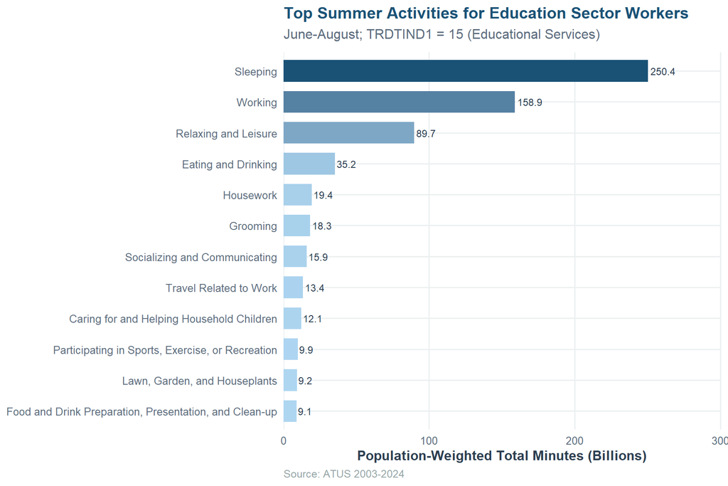

```r
# Filter to education sector workers in summer months.
# is_summer is on resp — join to act via participant_id.
edu_summer <- atus_act |>
  inner_join(
    atus_resp |>
      filter(in_education_sector, is_summer) |>
      select(participant_id, survey_weight),
    join_by(participant_id)) |>
  inner_join(codes_l2, join_by(level2_code == code_level2)) |>
  group_by(task_level2) |>
  summarize(total_wt_min = sum(time_spent_min * survey_weight, na.rm = TRUE),
            .groups = "drop") |>
  arrange(desc(total_wt_min)) |>
  slice_head(n = 12) |>
  mutate(task_level2 = fct_reorder(task_level2, total_wt_min))

ggplot(edu_summer, aes(x = total_wt_min / 1e9, y = task_level2,
                       fill = total_wt_min)) +
  geom_col(show.legend = FALSE, width = 0.7) +
  geom_text(aes(label = round(total_wt_min / 1e9, 1)),
            hjust = -0.1, size = 3.2, color = "#2c3e50") +
  scale_fill_gradient(low = "#aed6f1", high = "#1a5276") +
  scale_x_continuous(expand = expansion(mult = c(0, 0.2))) +
  labs(title   = "Top Summer Activities for Education Sector Workers",
       subtitle = "June-August; TRDTIND1 = 15 (Educational Services)",
       x = "Population-Weighted Total Minutes (Billions)", y = NULL,
       caption = "Source: ATUS 2003-2024")
```

**🎓 Educational Time by Age for College Students**

**🔍 Show Code**

[figure not shown]

```r
# code_level1 "060000" = Education
college_study <- atus_act |>
  filter(level1_code == "060000") |>
  inner_join(
    atus_resp |>
      filter(is_college_student) |>
      select(participant_id, survey_weight, age),
    join_by(participant_id)) |>
  filter(!is.na(age), age >= 18, age <= 55) |>
  mutate(age_group = cut(age,
    breaks = c(17, 22, 26, 30, 40, 55),
    labels = c("18-22\n(Traditional)","23-26","27-30","31-40","41-55"),
    right  = TRUE)) |>
  group_by(participant_id, age_group) |>
  summarize(daily_min    = sum(time_spent_min, na.rm = TRUE),
            survey_weight = first(survey_weight), .groups = "drop") |>
  group_by(age_group) |>
  summarize(avg_hrs = weighted.mean(daily_min / 60, survey_weight),
            se      = sd(daily_min / 60) / sqrt(n()), .groups = "drop")

ggplot(college_study, aes(x = age_group, y = avg_hrs, fill = age_group)) +
  geom_col(show.legend = FALSE, width = 0.65) +
  geom_errorbar(aes(ymin = avg_hrs - se, ymax = avg_hrs + se),
                width = 0.2, color = "#5d6d7e") +
  geom_text(aes(label = round(avg_hrs, 1)), vjust = -0.8,
            fontface = "bold", color = "#1a5276", size = 4) +
  scale_fill_manual(
    values = c("#aed6f1","#5dade2","#2e86c1","#1a5276","#0d2b3e")) +
  labs(title   = "Older College Students Invest More Time in Education",
       subtitle = "Avg daily hours on educational activities among ATUS enrollees",
       x = "Age Group", y = "Avg Hours / Day",
       caption = "Source: ATUS 2003-2024 | Error bars = +/- 1 SE")
```

**🏅 Bump Plot: Sports by Age Group**

**🔍 Show Code**

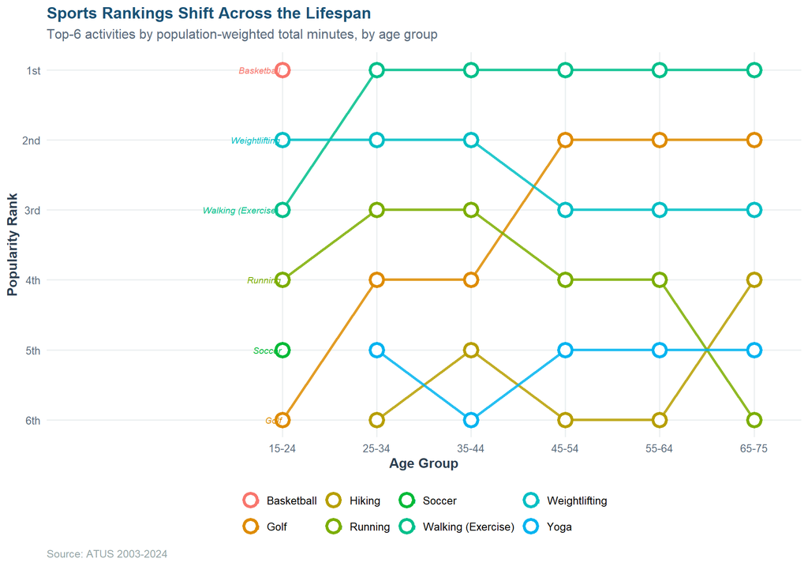

```r
# Specific level-3 sports codes from atus_activity_codes.csv
sport_codes <- tribble(
  ~level3_code, ~sport,
  "130103", "Basketball",
  "130114", "Golf",
  "130116", "Hiking",
  "130124", "Running",
  "130126", "Soccer",
  "130131", "Walking (Exercise)",
  "130133", "Weightlifting",
  "130136", "Yoga"
)

sports_by_age <- atus_act |>
  inner_join(sport_codes, join_by(level3_code)) |>
  inner_join(atus_resp |> select(participant_id, survey_weight, age),
             join_by(participant_id)) |>
  filter(!is.na(age), age >= 15, age <= 75) |>
  mutate(age_group = cut(age,
    breaks = c(14, 24, 34, 44, 54, 64, 75),
    labels = c("15-24","25-34","35-44","45-54","55-64","65-75"),
    right  = TRUE)) |>
  group_by(sport, age_group) |>
  summarize(total_wt = sum(time_spent_min * survey_weight, na.rm = TRUE),
            .groups = "drop") |>
  group_by(age_group) |>
  mutate(rank = rank(-total_wt, ties.method = "first")) |>
  ungroup() |>
  filter(rank <= 6)

ggplot(sports_by_age,
       aes(x = age_group, y = rank, group = sport, color = sport)) +
  geom_line(linewidth = 1.1, alpha = 0.85) +
  geom_point(size = 4.5, shape = 21, fill = "white", stroke = 2) +
  geom_text(data = sports_by_age |> filter(age_group == "15-24"),
            aes(label = sport, x = "15-24"),
            hjust = 1.05, size = 2.8, fontface = "italic") +
  scale_y_reverse(breaks = 1:6,
                  labels = c("1st","2nd","3rd","4th","5th","6th")) +
  scale_color_manual(values = scales::hue_pal()(12)) +
  scale_x_discrete(expand = expansion(add = c(2.5, 0.5))) +
  labs(title   = "Sports Rankings Shift Across the Lifespan",
       subtitle = "Top-6 activities by population-weighted total minutes, by age group",
       x = "Age Group", y = "Popularity Rank", color = NULL,
       caption = "Source: ATUS 2003-2024") +
  guides(color = guide_legend(nrow = 2))
```

**👶 Child Care Per Child by Family Size**

**🔍 Show Code**

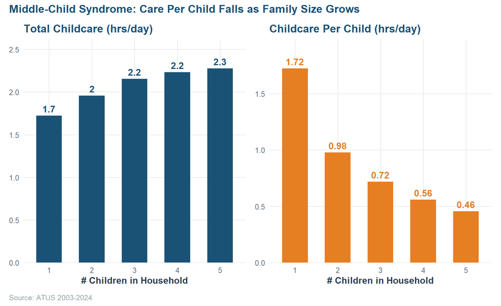

```r
# code_level1 "030000" = Caring for and Helping Household Members
childcare_per_child <- atus_act |>
  filter(level1_code == "030000") |>
  inner_join(
    atus_resp |>
      filter(n_children >= 1, n_children <= 5) |>
      select(participant_id, survey_weight, n_children),
    join_by(participant_id)) |>
  group_by(participant_id, n_children) |>
  summarize(daily_min    = sum(time_spent_min, na.rm = TRUE),
            survey_weight = first(survey_weight), .groups = "drop") |>
  mutate(per_child_min = daily_min / n_children) |>
  group_by(n_children) |>
  summarize(avg_total    = weighted.mean(daily_min, survey_weight),
            avg_per_child = weighted.mean(per_child_min, survey_weight),
            .groups = "drop")

p1 <- ggplot(childcare_per_child,
             aes(x = factor(n_children), y = avg_total / 60)) +
  geom_col(fill = "#1a5276", width = 0.6) +
  geom_text(aes(label = round(avg_total / 60, 1)), vjust = -0.5,
            color = "#1a5276", fontface = "bold") +
  labs(title = "Total Childcare (hrs/day)",
       x = "# Children in Household", y = NULL) +
  scale_y_continuous(expand = expansion(mult = c(0, 0.15)))

p2 <- ggplot(childcare_per_child,
             aes(x = factor(n_children), y = avg_per_child / 60)) +
  geom_col(fill = "#e67e22", width = 0.6) +
  geom_text(aes(label = round(avg_per_child / 60, 2)), vjust = -0.5,
            color = "#e67e22", fontface = "bold") +
  labs(title = "Childcare Per Child (hrs/day)",
       x = "# Children in Household", y = NULL) +
  scale_y_continuous(expand = expansion(mult = c(0, 0.15)))

(p1 | p2) +
  plot_annotation(
    title   = "Middle-Child Syndrome: Care Per Child Falls as Family Size Grows",
    caption = "Source: ATUS 2003-2024")
```

## 4 · Market Research: Target Demographics

Task 7

### 👨‍👧 Demographic 1: Stay-at-Home Dads

**Definition**: Males aged 25–55, not in the labor force, married (spouse present), with at least one child under 18.

Stay-at-home dads represent a growing demographic (~7% of fathers with children under 18).

**🔍 Show Code**

```r
sahd_ids <- atus_resp |>
  filter(
    sex == "Male",
    age %in% 25:55,
    employment_status == "Not in Labor Force",
    is_married,
    n_children >= 1
  ) |>
  select(participant_id, survey_weight, n_children)

sahd_act <- atus_act |>
  inner_join(sahd_ids, join_by(participant_id)) |>
  inner_join(codes_l1, join_by(level1_code == code_level1)) |>
  group_by(participant_id, task_level1) |>
  summarize(daily_min    = sum(time_spent_min, na.rm = TRUE),
            survey_weight = first(survey_weight), .groups = "drop") |>
  group_by(task_level1) |>
  summarize(low    = quantile(daily_min, 0.25),
            medium = weighted.mean(daily_min, survey_weight),
            high   = quantile(daily_min, 0.75), .groups = "drop") |>
  filter(task_level1 %in% c(
    "Caring for and Helping Household Members",
    "Household Activities",
    "Personal Care",
    "Eating and Drinking",
    "Sports, Exercise, and Recreation",
    "Socializing, Relaxing, and Leisure"
  )) |>
  mutate(
    target_min = case_match(task_level1,
      "Caring for and Helping Household Members" ~ 180,
      "Household Activities"                     ~ 120,
      "Personal Care"                            ~ 480,
      "Eating and Drinking"                      ~ 60,
      "Sports, Exercise, and Recreation"         ~ 45,
      "Socializing, Relaxing, and Leisure"       ~ 90,
      .default = 60),
    short_label = case_match(task_level1,
      "Caring for and Helping Household Members" ~ "Child Care",
      "Household Activities"                     ~ "Housework",
      "Personal Care"                            ~ "Sleep & Grooming",
      "Eating and Drinking"                      ~ "Meals",
      "Sports, Exercise, and Recreation"         ~ "Exercise",
      "Socializing, Relaxing, and Leisure"       ~ "Leisure",
      .default = task_level1),
    pct_hit = pnorm(target_min, mean = medium,
                    sd = pmax((high - low) / 1.35, 1),
                    lower.tail = FALSE)
  )

sahd_act |>
  select(short_label, low, medium, high, target_min, pct_hit) |>
  arrange(desc(medium)) |>
  gt() |>
  tab_header(title    = "Stay-at-Home Dad Time Use Profile",
             subtitle = "Daily minutes — typical range and aspirational targets") |>
  cols_label(short_label = "Activity", low = "25th %ile",
             medium = "Typical", high = "75th %ile",
             target_min = "Target", pct_hit = "% Hitting Target") |>
  fmt_number(columns = c(low, medium, high, target_min), decimals = 0) |>
  fmt_percent(columns = pct_hit, decimals = 0) |>
  data_color(columns = pct_hit, palette = c("#e74c3c","#f39c12","#27ae60")) |>
  tab_source_note("Targets based on pediatric and wellness recommendations")
```

Stay-at-Home Dad Time Use Profile

Daily minutes — typical range and aspirational targets

| Activity | 25th %ile | Typical | 75th %ile | Target | % Hitting Target |
| --- | --- | --- | --- | --- | --- |
| Sleep & Grooming | 503 | 596 | 670 | 480 | 83% |
| Leisure | 205 | 385 | 520 | 90 | 90% |
| Housework | 60 | 172 | 250 | 120 | 64% |
| Child Care | 45 | 144 | 210 | 180 | 38% |
| Exercise | 45 | 97 | 120 | 45 | 82% |
| Meals | 30 | 67 | 90 | 60 | 56% |

Targets based on pediatric and wellness recommendations

**Key insight**: Stay-at-home dads are positioned to be primary caregivers yet many fall short of recommended interactive play time. The app could gamify milestones — “You’re in the top 30% of hands-on dads this week!”

### 🎓 Demographic 2: College Undergraduates

**Definition**: Respondents enrolled in college or university (`is_college_student == TRUE`), aged 18–26.

**🔍 Show Code**

```r
undergrad_ids <- atus_resp |>
  filter(is_college_student, age %in% 18:26) |>
  select(participant_id, survey_weight)

undergrad_act <- atus_act |>
  inner_join(undergrad_ids, join_by(participant_id)) |>
  inner_join(codes_l1, join_by(level1_code == code_level1)) |>
  group_by(participant_id, task_level1) |>
  summarize(daily_min    = sum(time_spent_min, na.rm = TRUE),
            survey_weight = first(survey_weight), .groups = "drop") |>
  group_by(task_level1) |>
  summarize(low    = quantile(daily_min, 0.25),
            medium = weighted.mean(daily_min, survey_weight),
            high   = quantile(daily_min, 0.75), .groups = "drop") |>
  filter(task_level1 %in% c(
    "Education",
    "Personal Care",
    "Socializing, Relaxing, and Leisure",
    "Eating and Drinking",
    "Sports, Exercise, and Recreation",
    "Work and Work-Related Activities"
  )) |>
  mutate(
    target_min = case_match(task_level1,
      "Education"                          ~ 240,
      "Personal Care"                      ~ 480,
      "Socializing, Relaxing, and Leisure" ~ 90,
      "Eating and Drinking"                ~ 60,
      "Sports, Exercise, and Recreation"   ~ 45,
      "Work and Work-Related Activities"   ~ 60,
      .default = 60),
    short_label = case_match(task_level1,
      "Education"                          ~ "Studying & Class",
      "Personal Care"                      ~ "Sleep & Grooming",
      "Socializing, Relaxing, and Leisure" ~ "Socializing & Leisure",
      "Eating and Drinking"                ~ "Meals",
      "Sports, Exercise, and Recreation"   ~ "Exercise",
      "Work and Work-Related Activities"   ~ "Part-Time Work",
      .default = task_level1),
    pct_hit = pnorm(target_min, mean = medium,
                    sd = pmax((high - low) / 1.35, 1),
                    lower.tail = FALSE)
  )

undergrad_act |>
  select(short_label, low, medium, high, target_min, pct_hit) |>
  arrange(desc(medium)) |>
  gt() |>
  tab_header(title    = "College Undergraduate Time Use Profile",
             subtitle = "Daily minutes — typical range and aspirational targets") |>
  cols_label(short_label = "Activity", low = "25th %ile",
             medium = "Typical", high = "75th %ile",
             target_min = "Target", pct_hit = "% Hitting Target") |>
  fmt_number(columns = c(low, medium, high, target_min), decimals = 0) |>
  fmt_percent(columns = pct_hit, decimals = 0) |>
  data_color(columns = pct_hit, palette = c("#e74c3c","#f39c12","#27ae60")) |>
  tab_source_note("Study target based on 15-credit course load recommendation")
```

College Undergraduate Time Use Profile

Daily minutes — typical range and aspirational targets

| Activity | 25th %ile | Typical | 75th %ile | Target | % Hitting Target |
| --- | --- | --- | --- | --- | --- |
| Sleep & Grooming | 510 | 597 | 690 | 480 | 81% |
| Part-Time Work | 245 | 371 | 490 | 60 | 96% |
| Studying & Class | 120 | 303 | 390 | 240 | 62% |
| Socializing & Leisure | 137 | 265 | 390 | 90 | 82% |
| Exercise | 60 | 112 | 150 | 45 | 84% |
| Meals | 30 | 66 | 90 | 60 | 55% |

Study target based on 15-credit course load recommendation

### 🏙️ Demographic 3: Young Professionals (25–35, Full-Time Employed, No Kids)

**Definition**: Respondents aged 25–35, employed full-time (`is_full_time == TRUE`), no children in household.

**🔍 Show Code**

```r
yup_ids <- atus_resp |>
  filter(age %in% 25:35, is_full_time, n_children == 0) |>
  select(participant_id, survey_weight)

yup_act <- atus_act |>
  inner_join(yup_ids, join_by(participant_id)) |>
  inner_join(codes_l1, join_by(level1_code == code_level1)) |>
  group_by(participant_id, task_level1) |>
  summarize(daily_min    = sum(time_spent_min, na.rm = TRUE),
            survey_weight = first(survey_weight), .groups = "drop") |>
  group_by(task_level1) |>
  summarize(low    = quantile(daily_min, 0.25),
            medium = weighted.mean(daily_min, survey_weight),
            high   = quantile(daily_min, 0.75), .groups = "drop") |>
  filter(task_level1 %in% c(
    "Work and Work-Related Activities",
    "Personal Care",
    "Socializing, Relaxing, and Leisure",
    "Sports, Exercise, and Recreation",
    "Eating and Drinking",
    "Household Activities",
    "Volunteer Activities"
  )) |>
  mutate(
    target_min = case_match(task_level1,
      "Work and Work-Related Activities"   ~ 480,
      "Personal Care"                      ~ 450,
      "Socializing, Relaxing, and Leisure" ~ 90,
      "Sports, Exercise, and Recreation"   ~ 60,
      "Eating and Drinking"                ~ 60,
      "Household Activities"               ~ 45,
      "Volunteer Activities"               ~ 30,
      .default = 60),
    short_label = case_match(task_level1,
      "Work and Work-Related Activities"   ~ "Work",
      "Personal Care"                      ~ "Sleep & Grooming",
      "Socializing, Relaxing, and Leisure" ~ "Socializing & Leisure",
      "Sports, Exercise, and Recreation"   ~ "Exercise",
      "Eating and Drinking"                ~ "Meals",
      "Household Activities"               ~ "Chores",
      "Volunteer Activities"               ~ "Volunteering",
      .default = task_level1),
    pct_hit = pnorm(target_min, mean = medium,
                    sd = pmax((high - low) / 1.35, 1),
                    lower.tail = FALSE)
  )

yup_act |>
  select(short_label, low, medium, high, target_min, pct_hit) |>
  arrange(desc(medium)) |>
  gt() |>
  tab_header(title    = "Young Professional Time Use Profile",
             subtitle = "Ages 25-35, full-time employed, no children") |>
  cols_label(short_label = "Activity", low = "25th %ile",
             medium = "Typical", high = "75th %ile",
             target_min = "Target", pct_hit = "% Hitting Target") |>
  fmt_number(columns = c(low, medium, high, target_min), decimals = 0) |>
  fmt_percent(columns = pct_hit, decimals = 0) |>
  data_color(columns = pct_hit, palette = c("#e74c3c","#f39c12","#27ae60")) |>
  tab_source_note("Targets per WHO physical activity guidelines and burnout research")
```

Young Professional Time Use Profile

Ages 25-35, full-time employed, no children

| Activity | 25th %ile | Typical | 75th %ile | Target | % Hitting Target |
| --- | --- | --- | --- | --- | --- |
| Sleep & Grooming | 495 | 563 | 660 | 450 | 82% |
| Work | 406 | 488 | 568 | 480 | 53% |
| Socializing & Leisure | 130 | 245 | 380 | 90 | 80% |
| Volunteering | 60 | 135 | 180 | 30 | 88% |
| Chores | 30 | 97 | 150 | 45 | 72% |
| Exercise | 45 | 94 | 120 | 60 | 73% |
| Meals | 30 | 70 | 90 | 60 | 59% |

Targets per WHO physical activity guidelines and burnout research

**🔍 Show Code**

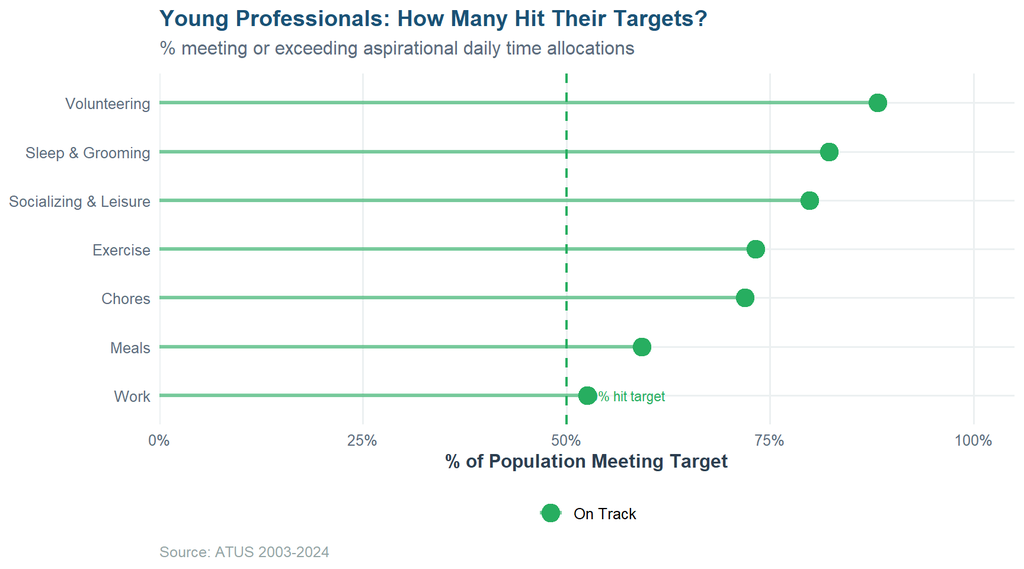

```r
yup_chart <- yup_act |>
  mutate(
    short_label = fct_reorder(short_label, pct_hit),
    status = case_when(
      pct_hit >= 0.5 ~ "On Track",
      pct_hit >= 0.3 ~ "Near Miss",
      TRUE           ~ "Needs Work"))

ggplot(yup_chart, aes(x = pct_hit, y = short_label, color = status)) +
  geom_segment(aes(x = 0, xend = pct_hit, yend = short_label),
               linewidth = 1.2, alpha = 0.6) +
  geom_point(size = 5) +
  geom_vline(xintercept = 0.5, linetype = "dashed",
             color = "#27ae60", linewidth = 0.8) +
  annotate("text", x = 0.52, y = 1, label = "50% hit target",
           color = "#27ae60", size = 3, hjust = 0) +
  scale_x_continuous(labels = percent_format(), limits = c(0, 1),
                     expand = expansion(mult = c(0, 0.05))) +
  scale_color_manual(
    values = c("On Track" = "#27ae60","Near Miss" = "#f39c12",
               "Needs Work" = "#e74c3c"), name = NULL) +
  labs(title   = "Young Professionals: How Many Hit Their Targets?",
       subtitle = "% meeting or exceeding aspirational daily time allocations",
       x = "% of Population Meeting Target", y = NULL,
       caption = "Source: ATUS 2003-2024")
```

## 5 · Conclusion

**NoteAI Usage Statement**

Claude (claude-sonnet-4-6) was used to assist with R code scaffolding, `ggplot2` visualizations, and `gt` table formatting. All narrative text, analytical interpretations, and analytical choices were developed independently. All code was reviewed and understood before submission.